# Incarceration Statistics in the US

Cole Graham

## Introduction to the Issue

The US has a history of racist/prejudice arrests and court decisions resulting in an alarming number of minorities residing in jails and prisons. To evaluate this problem, I chose to look at many statistics pertaining to the jailing of black people in the US and more specifically, Washington. To do those I looked at the black jail population, total jail population, white jail poulation, as well as state, and county statistics.

## Summary Information

To better understand the data and its implications, it was important to find some data that would allow for a more clear frame of mind. The first year the data reports is 1970 and the last year is 2018. There are 1876 counties with information recorded across 4 recognized regions (South, West, Northeast, Midwest). In addition, this data set is fairly large with 153,811 rows.

## Trends Over Time Chart

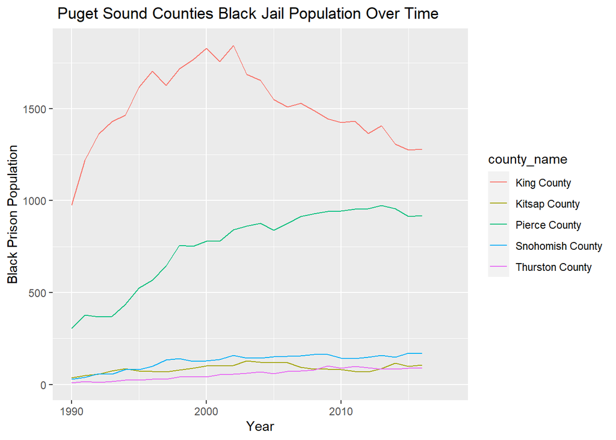

This chart shows the black jail population of counties around the Puget Sound. As expected, King county has the highest number as it also has the highest population. It is important to note that the number peaked in king county in the early 2000s and has been declining since (still above 1990 levels), while the number has been rising in pierce county since 1990. Other counties are also generally showing an increase since 1990 but not as drastic as Pierce county. I decided to include this chart so I could determine how often different areas in close to UW are arresting black people and if it is a notable problem. It is good to see that the numbers in King County are decreasing, but it is alamring how fast they are increasing in Pierce County.

## Variable Comparison Chart

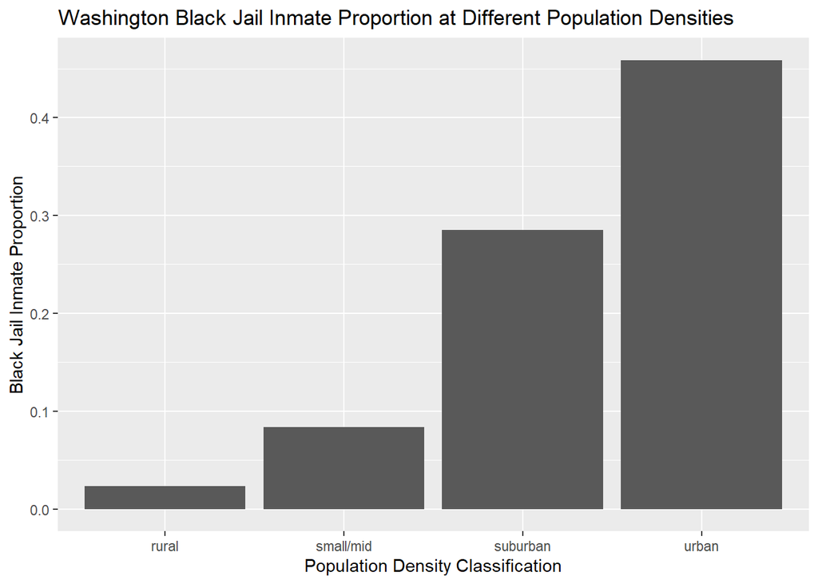

Next, I created a proportion that compared the number of black jail inmates to total jail inmates across rural, small/mid, suburban, and urban areas to see if there was a relation (which I hypothesized would there would be). These variables seem to be connected, as the population density classification went up, so did the proportion, meaning that jails were more black dominant where the population is more dense. This could be because, generally, the black population is higher in urban areas, but could also highlight potential law enforcement approaches that could be problematic. I decided to include this chart as it shows a relationship between population density and proportion of black inmates. Specifically, it highlights the shockingly high rate of over 45% in urban areas.

## Map

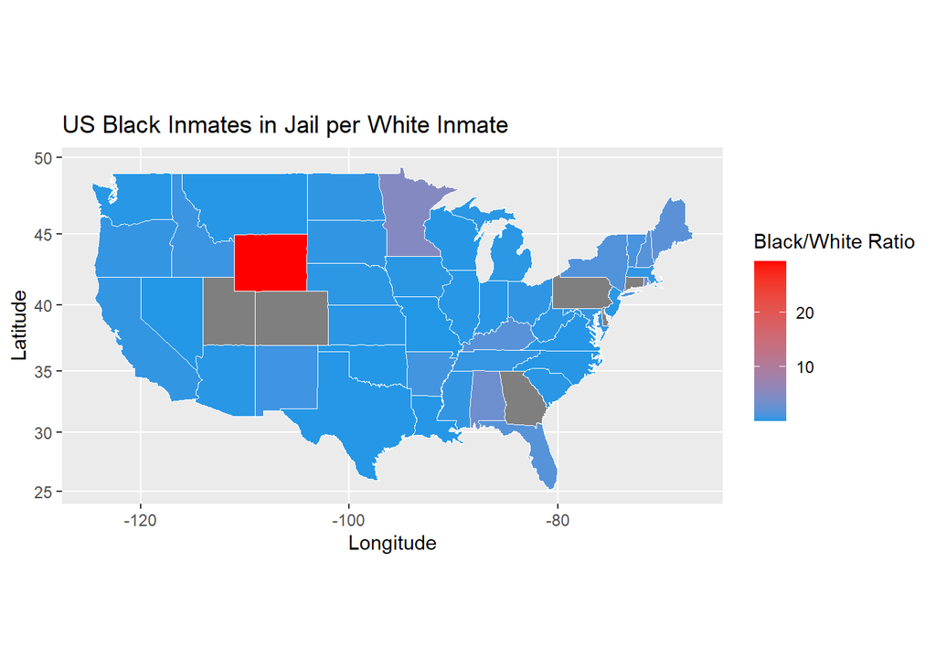

This map shows the proprtion of black inmates in jail to white inmates in jail across the 48 cotinuous states. This allowed for me to see which states have disportportionate amount of black jail inmates. It seem the Wyoming has an alarming amount of Black inmates compared to White as it is northwards of 25, while many states seem to be lower (below and near 1). Other states such as Minnesota, Alabama, and Rhode Island are fairly high with a ratio upwards of 3. I decided to create this map so I could see what states are primary culprits of the jailing crisis.